# Mixed Models Assignment

“We tracked eight adult northern lapwings, Vanellus vanellus, (six females and two males) from a Dutch breeding colony by light-level geolocation year-round, three of them for multiple years. We show that birds breeding virtually next to each other may choose widely separated wintering grounds, stretching from nearby the colony west towards the UK and Ireland, and southwest through France into Iberia and Morocco. However, individual lapwings appeared relatively faithful to a chosen wintering area, and timing of outward and homeward migration can be highly consistent between years. Movements of migratory individuals were usually direct and fast, with some birds covering distances of approximately 2000 km within 2 to 4 days of travel. The two males wintered closest and returned earliest to the breeding colony. The female lapwings returned well before the onset of breeding, spending a pre-laying period of 19 to 54 days in the wider breeding area. Despite the potential for high migration speeds, the duration that birds were absent from the breeding area increased with distance to wintering areas, a pattern which was mainly driven by an earlier outward migration of birds heading for more distant wintering grounds. Moreover, females that overwintered closer to colony bred earlier. A large variation in migration strategies found even within a single breeding colony has likely supported the species’ responsiveness to recent climate change as evidenced by a shortened migration distance and an advanced timing of reproduction in Dutch lapwings since the middle of the 20th century (Eichhorn et al., 2017).”

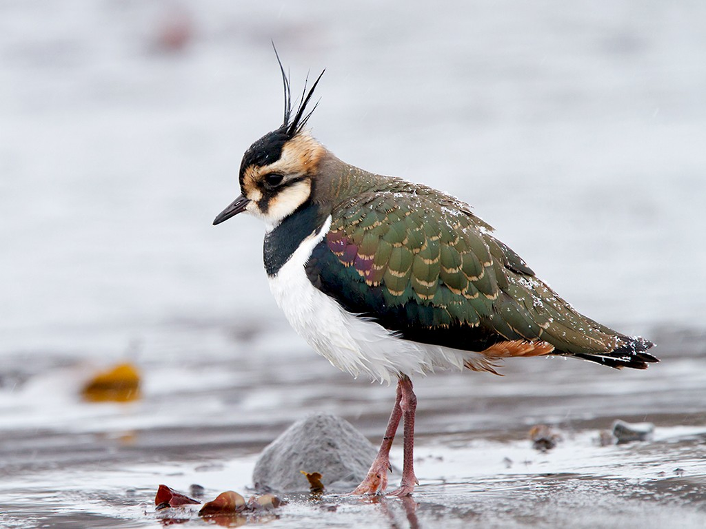

Figure 1. Northern Lapwing (Vanellus vanellus)

```r
summary_lapwing1 <- lapwing1  %>%
  group_by(Bird, Year) %>%
  summarise(n = n(),
           mean_Distance_Colony_AVG=mean(Distance_Colony_AVG),
           se_Distance_Colony_AVG=sd(Distance_Colony_AVG)/sqrt(n()))
summary_lapwing1
```

```
## # A tibble: 24 x 5
## # Groups:   Bird [8]
##    Bird  Year      n mean_Distance_Colony_AVG se_Distance_Colony_AVG
##    <fct> <chr> <int>                    <dbl>                  <dbl>
##  1 GEBL  YearA     1                     807.                     NA
##  2 GEBL  YearB     1                     642.                     NA
##  3 GEBL  YearC     1                     797.                     NA
##  4 GROR  YearA     1                    1693.                     NA
##  5 GROR  YearB     1                    1235.                     NA
##  6 GROR  YearC     1                    1199.                     NA
##  7 ORWI  YearA     1                     778.                     NA
##  8 ORWI  YearB     1                     671.                     NA
##  9 ORWI  YearC     1                     758.                     NA
## 10 WIBL  YearA     1                     219.                     NA
## # ... with 14 more rows
```

```r
years_means <- lapwing1 %>%
  group_by(Year) %>%
  summarise(mean_Distance_Colony_AVG=mean(Distance_Colony_AVG),
            se_Distance_Colony_AVG=sd(Distance_Colony_AVG)/sqrt(n()))
years_means
```

```
## # A tibble: 3 x 3
##   Year  mean_Distance_Colony_AVG se_Distance_Colony_AVG
##   <chr>                    <dbl>                  <dbl>
## 1 YearA                     956.                   179.
## 2 YearB                     909.                   131.
## 3 YearC                     910.                   111.
```

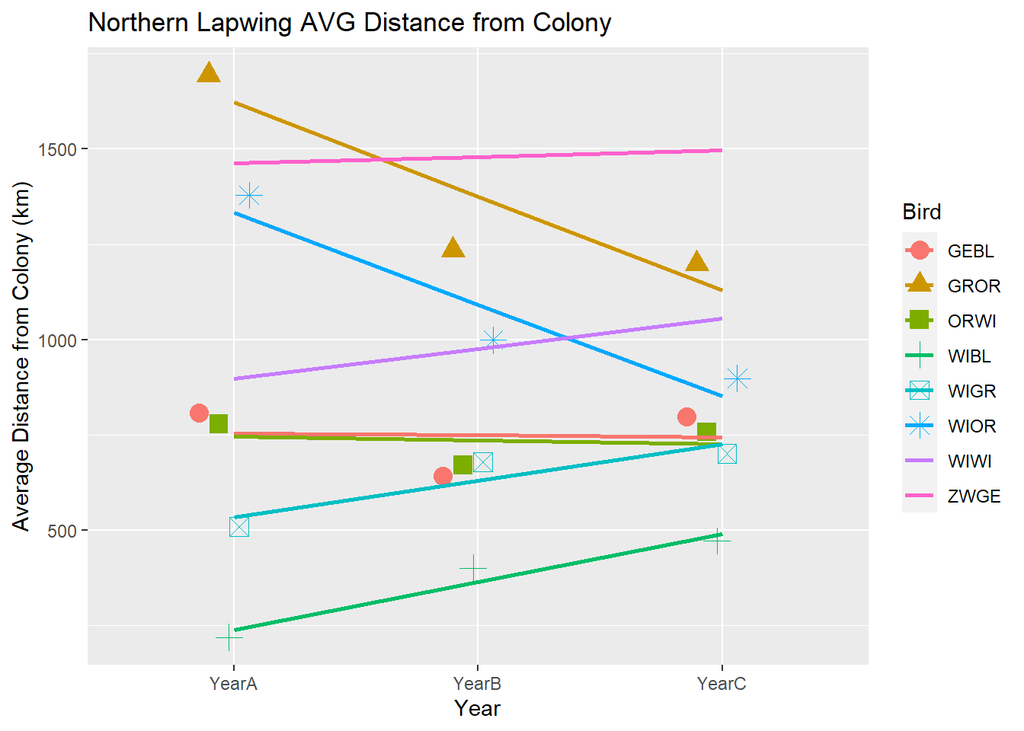

```r
p1<- ggplot(lapwing1, aes(x=Year, y=Distance_Colony_AVG, group=Bird, color=Bird, shape=Bird)) +
  geom_point(size=4, position = position_dodge2(width=.33, preserve = "total")) +
  scale_y_continuous() +
  #geom_line() +
  geom_smooth(method = "lm", se = FALSE) +
  labs(title="Northern Lapwing AVG Distance from Colony", x= "Year", y = "Average Distance from Colony (km)")

p1
```

```r
mixed_lapwing1 <- lmer(Distance_Colony_AVG ~ Year + (1|Bird), data = lapwing1)
```

#Looking at relationship between fixed effects: AVG Distance from Colony and Year with individual Bird as a random effect

```r
summary(mixed_lapwing1)
```

```
## Linear mixed model fit by REML. t-tests use Satterthwaite's method [
## lmerModLmerTest]
## Formula: Distance_Colony_AVG ~ Year + (1 | Bird)
##    Data: lapwing1
##
## REML criterion at convergence: 300.6
##
## Scaled residuals:
##      Min       1Q   Median       3Q      Max
## -1.25105 -0.56958  0.07542  0.35822  1.85861
##
## Random effects:
##  Groups   Name        Variance Std.Dev.
##  Bird     (Intercept) 134690   367.0
##  Residual              29122   170.7
## Number of obs: 24, groups:  Bird, 8
##
## Fixed effects:
##             Estimate Std. Error      df t value Pr(>|t|)
## (Intercept)  955.912    143.096   8.928   6.680  9.4e-05 ***
## YearYearB    -46.547     85.326  14.000  -0.546    0.594
## YearYearC    -46.140     85.326  14.000  -0.541    0.597
## ---
## Signif. codes:  0 '***' 0.001 '**' 0.01 '*' 0.05 '.' 0.1 ' ' 1
##
## Correlation of Fixed Effects:
##           (Intr) YerYrB
## YearYearB -0.298
## YearYearC -0.298  0.500
```

#Check under random effects #of observations: 24 obs, 8 Birds #Look at fixed effects: Average Distance from the Colony in Year A was 46.547 higher than Year B and 46.140 higher than Year C

```r
anova(mixed_lapwing1)
```

```
## Type III Analysis of Variance Table with Satterthwaite's method
##      Sum Sq Mean Sq NumDF DenDF F value Pr(>F)
## Year  11455  5727.5     2    14  0.1967 0.8237
```

#Check p-value

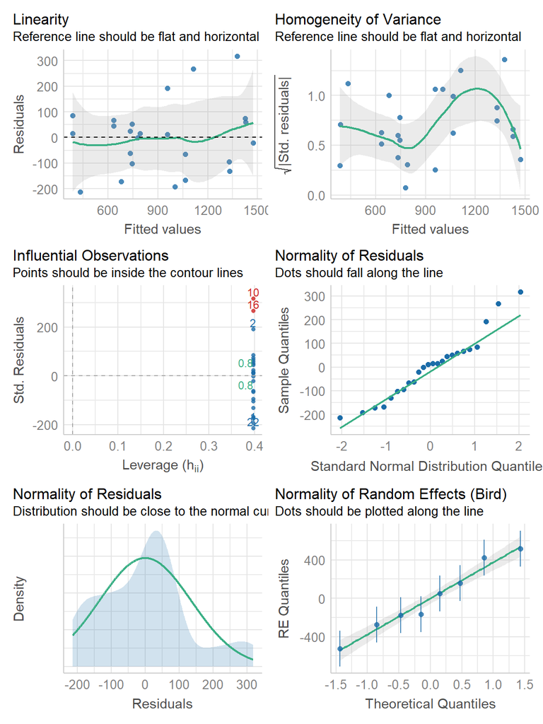

```r
performance::check_model(mixed_lapwing1)
```

```r
#calculate model-adjusted means (e.g. estimated marginal means)
mixed_lapwing1_emm <- emmeans(mixed_lapwing1, "Year")
```

```r
mixed_lapwing1_emm
```

```
##  Year  emmean  SE   df lower.CL upper.CL
##  YearA    956 143 8.93      632     1280
##  YearB    909 143 8.93      585     1233
##  YearC    910 143 8.93      586     1234
##
## Degrees-of-freedom method: kenward-roger
## Confidence level used: 0.95
```

```r
years_means
```

```
## # A tibble: 3 x 3
##   Year  mean_Distance_Colony_AVG se_Distance_Colony_AVG
##   <chr>                    <dbl>                  <dbl>
## 1 YearA                     956.                   179.
## 2 YearB                     909.                   131.
## 3 YearC                     910.                   111.
```

```r
pairs(emmeans(mixed_lapwing1, "Year"))
```

```
##  contrast      estimate   SE df t.ratio p.value
##  YearA - YearB   46.547 85.3 14   0.546  0.8504
##  YearA - YearC   46.140 85.3 14   0.541  0.8528
##  YearB - YearC   -0.408 85.3 14  -0.005  1.0000
##
## Degrees-of-freedom method: kenward-roger
## P value adjustment: tukey method for comparing a family of 3 estimates
```

#emmeans comparisons between the years.

Part Two

“Carotenoid pigments are found in the retinas of many vertebrate species, where they serve a range of functions. In birds, carotenoid-containing retinal oil droplets act as optical filters, modifying the light reaching the underlying visual pigment and thereby enhancing color vision. Dietary carotenoid manipulation is known to affect the allocation of carotenoids to the retina, although the effects this has on vision are less well understood. Using dietary manipulations, in which juvenile Japanese quail (Coturnix japonica) received either a high- or a low-carotenoid diet, we tested the effects of carotenoid availability on the ability to perform a color discrimination task. Birds on both diet treatments were able to make a relatively coarse discrimination between colors that appeared to humans as yellow-orange and orange; however, only high-carotenoid diet birds were able to make a finer-scale discrimination involving intermediate colors, showing that dietary carotenoid availability can directly affect the ability of birds to make chromatic discriminations. This finding has implications for our understanding of trade-offs in carotenoid allocation between vision and other key functions such as sexual ornamentation and health maintenance, and suggests that variation in dietary carotenoid availability may affect the ability of animals to make ecologically pertinent color discriminations, such as between sexual signals or cryptic food items (Lim et al., 2016).”

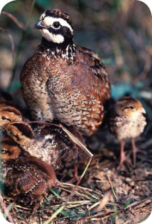

Figure 2. Japanese Quail (Coturnix japonica)

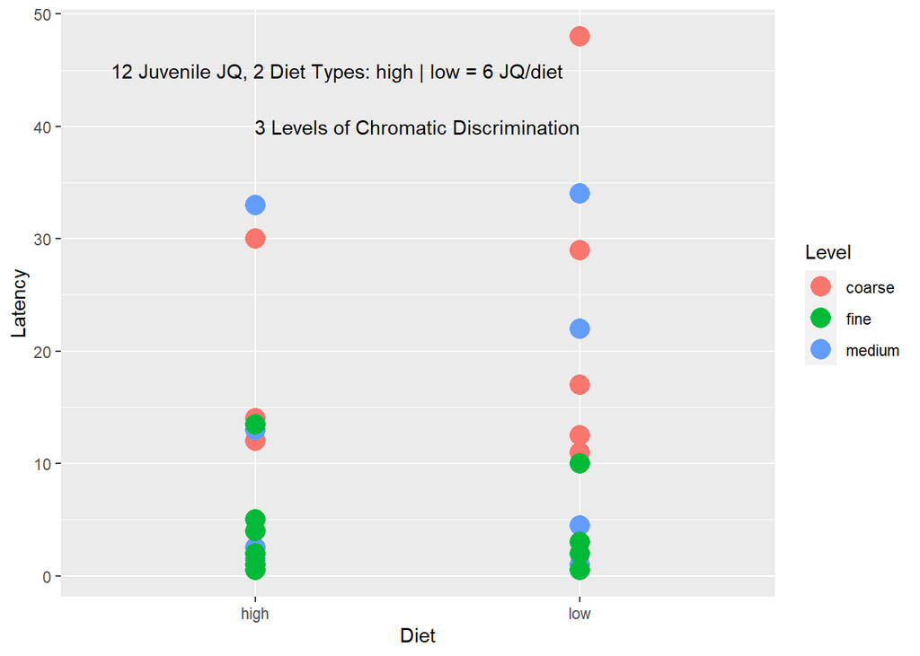

```r
ggplot(Carotenoid_Diet, aes(Diet, Latency, colour = Level)) +
  geom_point(size=5) +
   annotate("text", x = 1.25, y = 45, label = "12 Juvenile JQ, 2 Diet Types: high | low = 6 JQ/diet") +
  annotate("text", x = 1.5, y = 40, label = "3 Levels of Chromatic Discrimination")
```

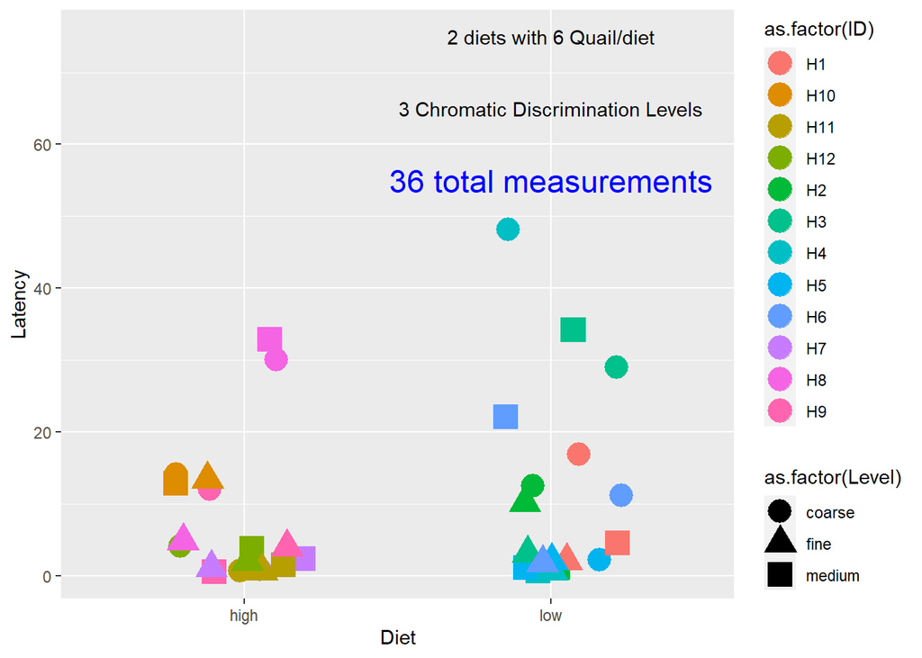

```r
ggplot(Carotenoid_Diet, aes(Diet, Latency, colour = as.factor(ID), shape=as.factor(Level))) +
  geom_jitter(width =0.25, size=6) +
  annotate("text", x = 2, y = 75, label = "2 diets with 6 Quail/diet") +
  annotate("text", x = 2, y = 65, label = "3 Chromatic Discrimination Levels") +
  annotate("text", x = 2, y = 55, label = "36 total measurements", size=6, color="blue")
```

#“First, lets do it the wrong way and show how pseudoreplication can result in incorrect analyses. Of primary interest is the detection of differences in the fixed factor of diet. By treating each measure in each liver preparation in each rat as independent observations, we get a model with inflated degrees of freedom (Aho, 2014).”

```r
anova(lm(Latency ~ Diet, data = Carotenoid_Diet))
```

```
## Analysis of Variance Table
##
## Response: Latency
##           Df Sum Sq Mean Sq F value Pr(>F)
## Diet       1  100.0  100.00  0.6967 0.4097
## Residuals 34 4880.4  143.54
```

#The analysis tells us that df = 34

#There are 12 juvenile Japanese Quail in this experiement

#“Pseudoreplication has artificially inflated sample sizes, and increased the probability of type I error. Using a mixed-model approach, we can obtain variance components estimates for the model (Aho, 2014).”

```r
quail.1 <- lmer(Latency ~ Diet * Level + (1|ID), data = Carotenoid_Diet)
quail.1
```

```
## Linear mixed model fit by REML ['lmerModLmerTest']
## Formula: Latency ~ Diet * Level + (1 | ID)
##    Data: Carotenoid_Diet
## REML criterion at convergence: 240.8344
## Random effects:
##  Groups   Name        Std.Dev.
##  ID       (Intercept)  5.305
##  Residual             10.133
## Number of obs: 36, groups:  ID, 12
## Fixed Effects:
##         (Intercept)              Dietlow            Levelfine
##              10.250                9.667               -5.917
##         Levelmedium    Dietlow:Levelfine  Dietlow:Levelmedium
##              -1.167              -10.750               -8.250
```

```r
summary(quail.1)
```

```
## Linear mixed model fit by REML. t-tests use Satterthwaite's method [
## lmerModLmerTest]
## Formula: Latency ~ Diet * Level + (1 | ID)
##    Data: Carotenoid_Diet
##
## REML criterion at convergence: 240.8
##
## Scaled residuals:
##     Min      1Q  Median      3Q     Max
## -1.3426 -0.5293 -0.1400  0.2849  2.5439
##
## Random effects:
##  Groups   Name        Variance Std.Dev.
##  ID       (Intercept)  28.14    5.305
##  Residual             102.67   10.133
## Number of obs: 36, groups:  ID, 12
##
## Fixed effects:
##                     Estimate Std. Error      df t value Pr(>|t|)
## (Intercept)           10.250      4.669  27.458   2.195   0.0368 *
## Dietlow                9.667      6.603  27.458   1.464   0.1546
## Levelfine             -5.917      5.850  20.000  -1.011   0.3239
## Levelmedium           -1.167      5.850  20.000  -0.199   0.8439
## Dietlow:Levelfine    -10.750      8.273  20.000  -1.299   0.2086
## Dietlow:Levelmedium   -8.250      8.273  20.000  -0.997   0.3306
## ---
## Signif. codes:  0 '***' 0.001 '**' 0.01 '*' 0.05 '.' 0.1 ' ' 1
##
## Correlation of Fixed Effects:
##             (Intr) Dietlw Levlfn Lvlmdm Dtlw:Lvlf
## Dietlow     -0.707
## Levelfine   -0.626  0.443
## Levelmedium -0.626  0.443  0.500
## Ditlw:Lvlfn  0.443 -0.626 -0.707 -0.354
## Dtlw:Lvlmdm  0.443 -0.626 -0.354 -0.707  0.500
```

#Check random effects # of observations: 36, groups: ID, 12 #*interaction between diet and level of chromatic discrimination #The high diet is compared here, showing latency in diet high is 10.750 higher than Dietlow:Levelfine and 8.250 more than Dietlow:Levelmedium

```r
anova(quail.1)
```

```
## Type III Analysis of Variance Table with Satterthwaite's method
##            Sum Sq Mean Sq NumDF DenDF F value  Pr(>F)
## Diet        54.87   54.87     1    10  0.5345 0.48152
## Level      766.01  383.01     2    20  3.7304 0.04199 *
## Diet:Level 189.87   94.94     2    20  0.9247 0.41297
## ---
## Signif. codes:  0 '***' 0.001 '**' 0.01 '*' 0.05 '.' 0.1 ' ' 1
```

#Look at P-value here: Level was significant with the p-value of 0.04199

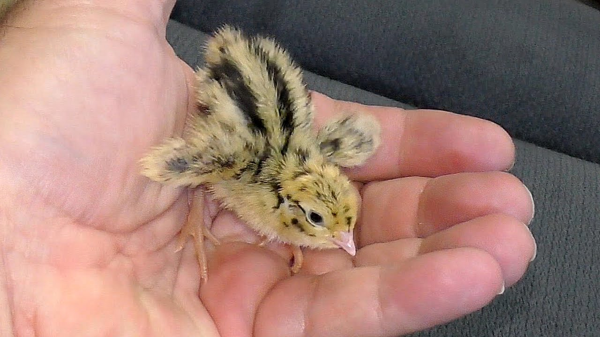

Figure 3. Japanese Quail (Coturnix japonica) nestling